# KICKSTARTER ANALYSIS

Tuesday, April 16, 2019

## Introduction: What is *Kickstarter*?

- *Kickstarter* is a funding platform for creative projects.
  - Everything from films, games, and music to art, design, and technology.
  - Full of ambitious, innovative, and imaginative ideas that are brought to life through the direct support of others.
- Everything on *Kickstarter* must be a project with a clear goal, like making an album, a book, or a work of art. A project will eventually be completed, and something will be produced by it.

## Introduction: What is *Kickstarter*?

- *Kickstarter's* 'All or Nothing' Rule
  - A creator can only collect the funds if the funding goal has been reached by the deadline. If the goal is not reached in time, no money changes hands.
- Succsesful campaigns are able to succesfully croudsource all of the funding that they designate within the set timeframe
- Failed campaigns were unable to gather enough support for their idea/product and the money is sent back to the public backers

## Our Data

- Source: https://webrobots.io/kickstarter-datasets/
- Number of rows: 2,553,392
- Number of columns: 37
  - Important columns:
    - Category
    - State
    - Blurb
    - urls
- Timespan of Data: 2015 - 2019
- Auxillary Data source: https://github.com/nalamidi/Kickstarter-Predictive-Analysis/tree/master/Kickstarter

## The Question We Set Out To Answer:

## What indicates whether a campaign will be successful or not?

## Exploratory Data Analysis

## State of Campaigns by Percentage

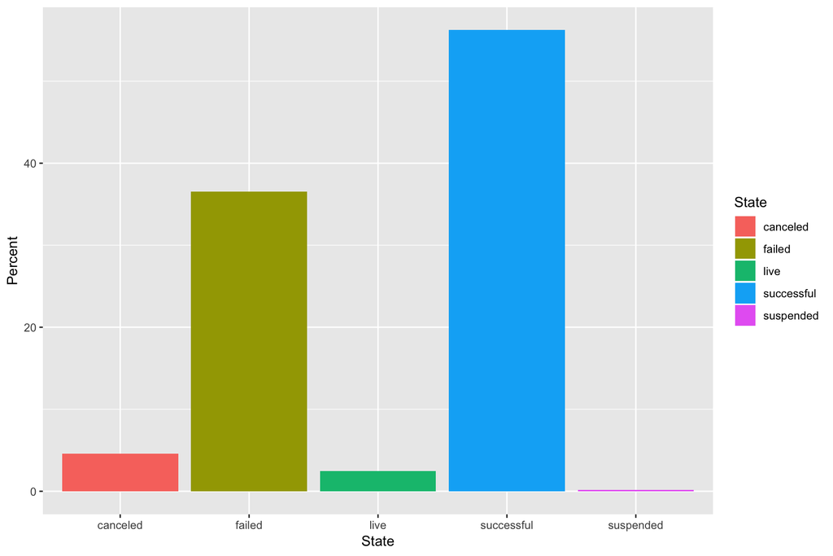

## Campaigns by Category

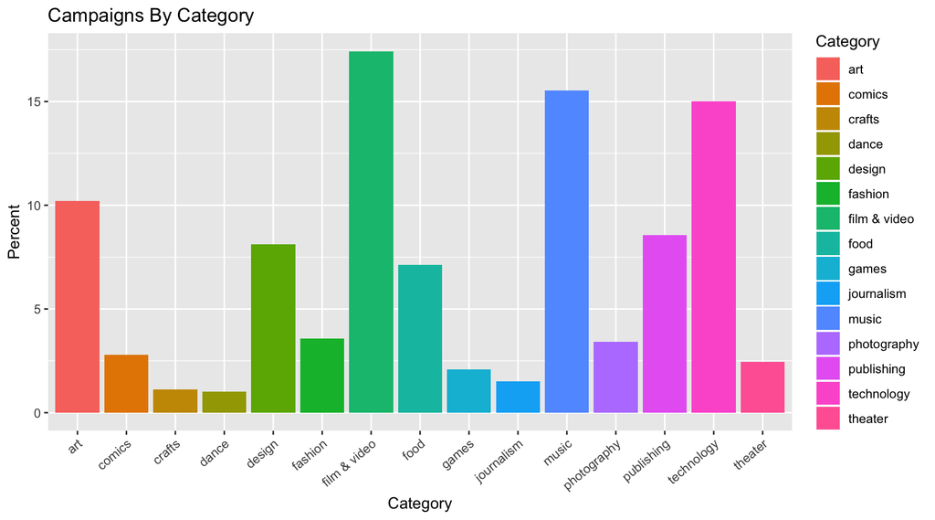

## Top 15 Categories

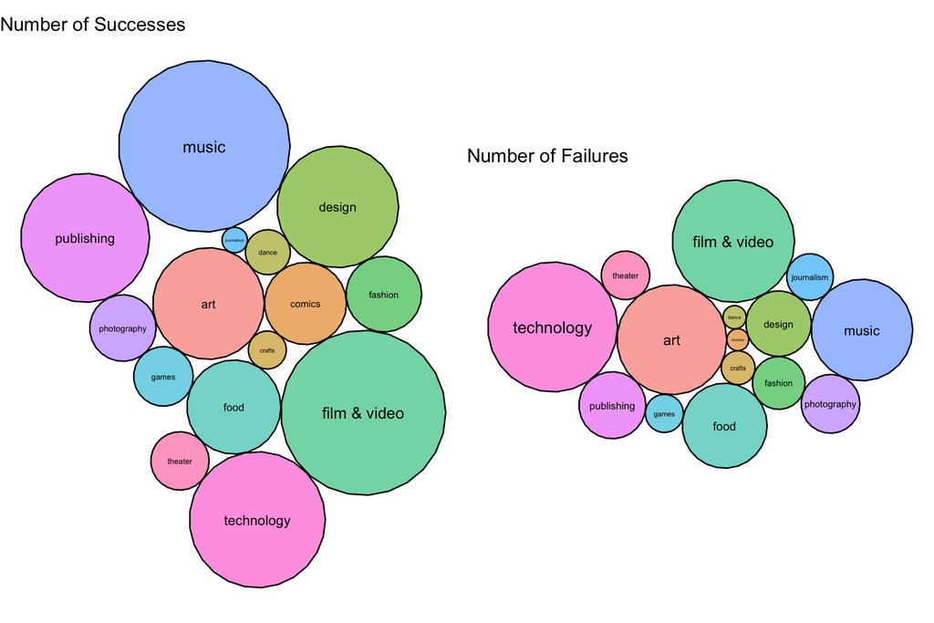

## Geographic Distribution

## Fundraising Goals by Country

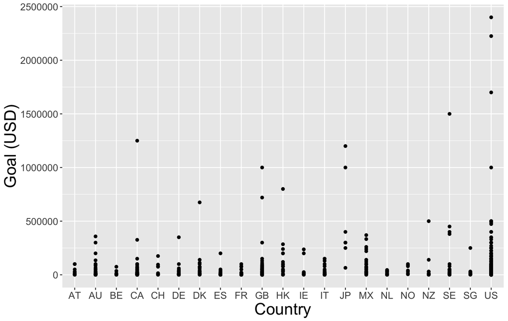

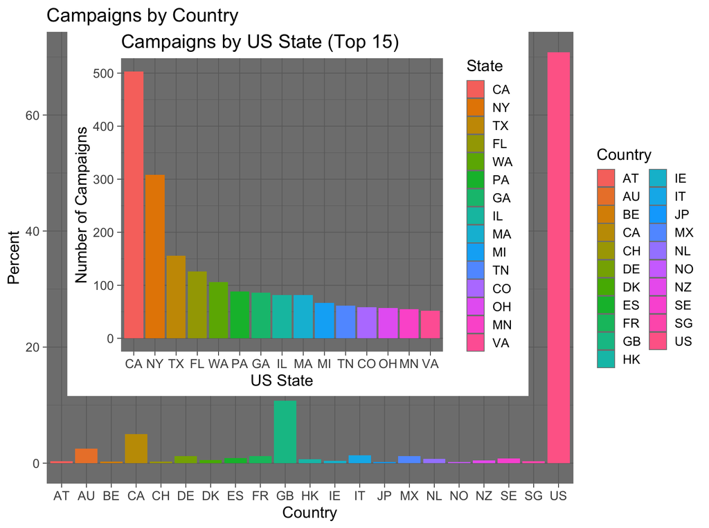

## Reward Levels

- Kickstarter campaigns offer different levels of rewards for backers who invest at different levels
- Our secondary dataset included the number of levels offered by each campaign
- Is there a relationship between the number of reward levels offered and campaign success?

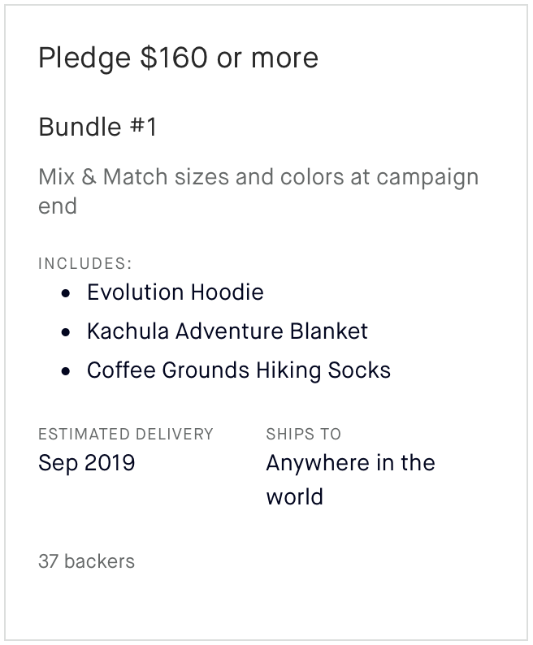

## How Reward Levels Impact Success

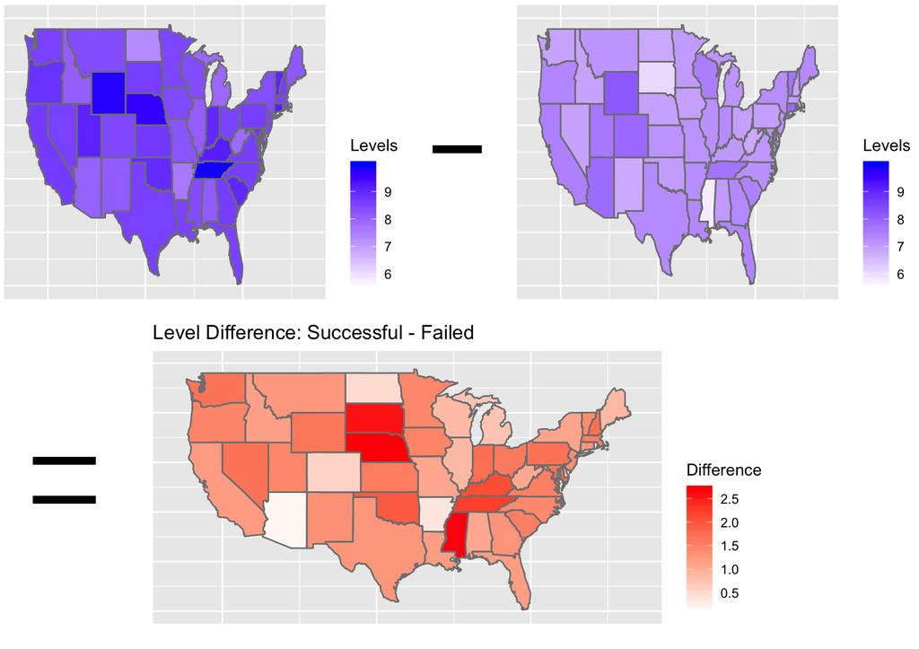

## Language Processing: Keywords

- The word "first" can be found in the descriptions of:
  - 5.6% of successful campaigns
  - 3.4% of failed campaigns
- These aren't huge numbers, it's a 65% increase from failed to successful and it is only one word
- Exclamation marks can be found in the descriptions of:
  - 26.7% of successful campaigns
  - 21.8% of failed campaigns
- Successful campaigns are 22% more likely to contain an exclamation mark
- Overall, simply using a key word doesn't translate to campaign success

## Community Interest: Comments

## Violin Plot of Failure vs Success

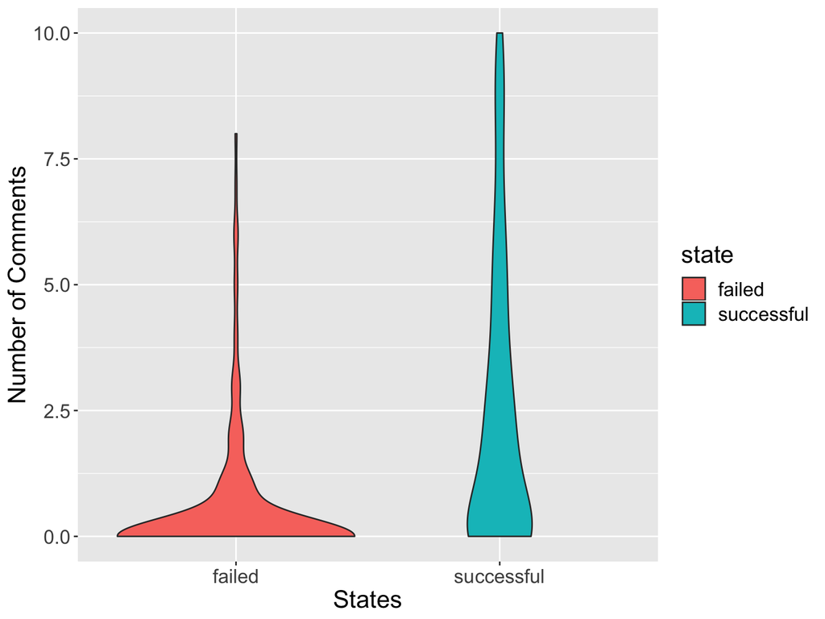

## Conclusion

- What indicates whether a campaign will be successful or not?
  - Categorical analysis
    - Music … Comics … Publishing
  - Geographical analysis
    - Location doesn't matter
    - But more levels help
  - Various words in the blurb
    - First … ! … Best
  - Comments on the campaign's web page
    - More comments = more likely to be successful

## Questions?

## Sources

- https://help.kickstarter.com/hc/en-us/articles/115004996453-What-is-Kickstarter-